# Workplace Safety and Work/Life Balance

PUBADM 505

2026-11-09

## Outline

- Workplace safety
- Work/life balance
- After the break: The Blast in Centralia No. 5

## Workplace Safety

## State and Local Jobs Are Riskier Than Private Ones

4.4

state and local government

2.3

private industry

Nonfatal injuries and illnesses per 100 full-time workers, 2024

Why would a government job be nearly twice as likely to hurt you?

U.S. Bureau of Labor Statistics, Employer-Reported Workplace Injuries and Illnesses, 2024 (national rates as reported in BLS regional releases, Feb. 2026).

## Who Protects You Depends on Who You Work For

Private and nonprofit

Federal OSHA sets the standards, inspects, and can fine

Federal

Each agency runs its own program. OSHA inspects but can’t fine

Idaho state and local

Federal OSHA doesn’t cover them, and Idaho has no OSHA-approved State Plan

Occupational Safety and Health Act of 1970; Exec. Order No. 12196; OSHA, State Plans.

## Safety Starts with a Risk Assessment

Find the risks

Health, safety, information security, legal

→

Make a plan

What to prevent, and what to do if it happens

→

Name an owner

A risk manager runs it across departments

→

Keep it current

Audits, updated policies, lessons from incidents

## Bullying, Harassment, and Violence Are Different Problems

Bullying

Repeated, intentional misuse of power to humiliate or undermine someone

Harassment

Unwelcome conduct based on a protected trait, which the law covers. See last week

Violence

An act or threat at work, from verbal abuse to physical assault

You see it happen to a coworker. What’s your role?

## Preventing Violence Takes More Than a Policy

A clear policy

Prevention, response, care for victims

Training

Especially for supervisors

Threat assessment team

HR, security, legal, EAP, the union

Crucial conversations

Deal with conflict before it escalates

See something, say something

Minor incidents get reported too

Trust

People believe a report will be acted on

## Activity: Find It

Boise State is your employer. Use your phones.

1. Is there a workplace violence policy? When was it last updated?
2. Where would you report a threat?
3. What training is offered?

6 minutes in groups, then tell us how hard it was to find

## Work/Life Balance

## Work/Life Conflict Is About Scarce Resources

People protect their time, energy, and attention. Conflict is what happens when one role drains what another needs.

Work → family

Family → work

Role overload

Caregiver strain

Isn’t this the employee’s problem? Why should the employer care?

## More Than Family-Friendly

Education

Tuition help

Family

Child and elder care

Flextime, flexplace

Schedules, telework

Insurance

Health, life

Wellness

Fitness, stress

Leave

Parental, volunteer

Transit

Passes, parking

EAP

Confidential counseling

Which would you look for first? Would your answer change in five years?

## Federal Telework Grew, Then a Memo Ordered It Back

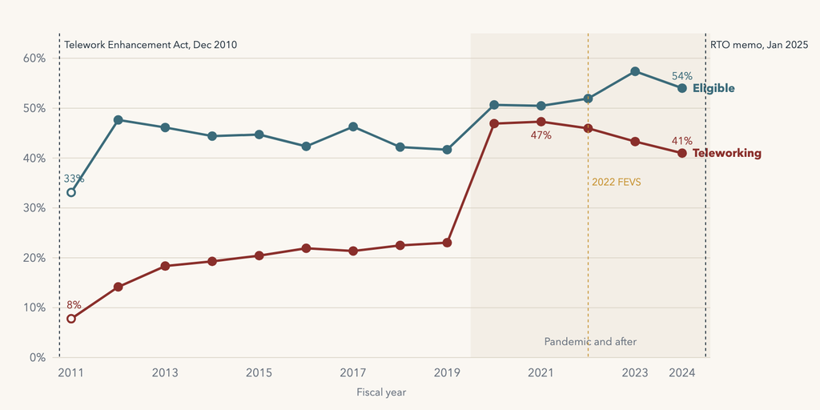

Share of all employees, from OPM’s *Status of Telework* reports; matched-agency weighted rates, not official totals. Return to In-Person Work memorandum, Jan. 20, 2025.

## Telework Works for the Teleworker. What About the Rest?

What we know

Teleworkers tend to be more satisfied. A randomized trial found no loss in performance ratings

What’s missing

Most studies measure the person who went remote, not the coworkers still in the office

Why government is different

Public goals are vague by design. Managers and coworkers fill them in, every day, in the work unit

Gajendran and Harrison (2007); Bloom, Han, and Liang (2024); Chun and Rainey (2005); Pandey and Wright (2006); Fowler and Birdsall (2025).

## My Research: What Happens to the People Who Stay?

Do onsite employees in hybrid units report less goal clarity than onsite employees in fully onsite units?

The data

2022 Federal Employee Viewpoint Survey: 438,928 employees

The key question

“How do employees in your work unit report to work?”

Goal clarity

Know the unit’s goals, understand priorities, managers communicate them. 0–100

Birdsall and Fowler, working paper.

## Frequent Teleworkers Report the Clearest Goals

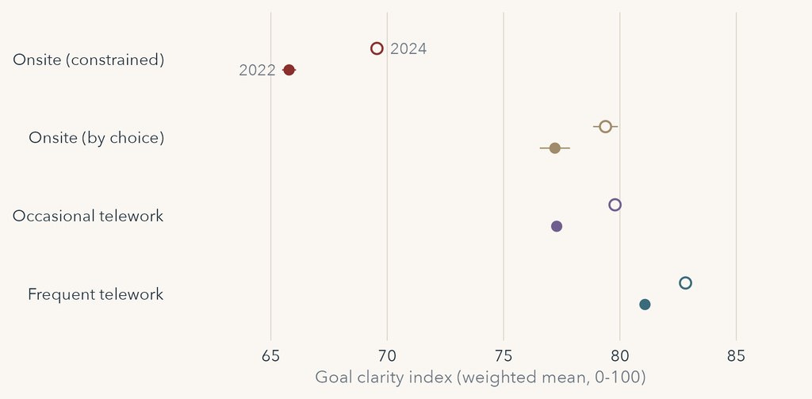

Constrained: onsite because the job, technology, or a denied request requires it. Weighted means; filled = 2022 (N = 438,928), hollow = 2024 (N = 513,962). Birdsall and Fowler, working paper.

## In Hybrid Units, the People Onsite Report Less Clarity

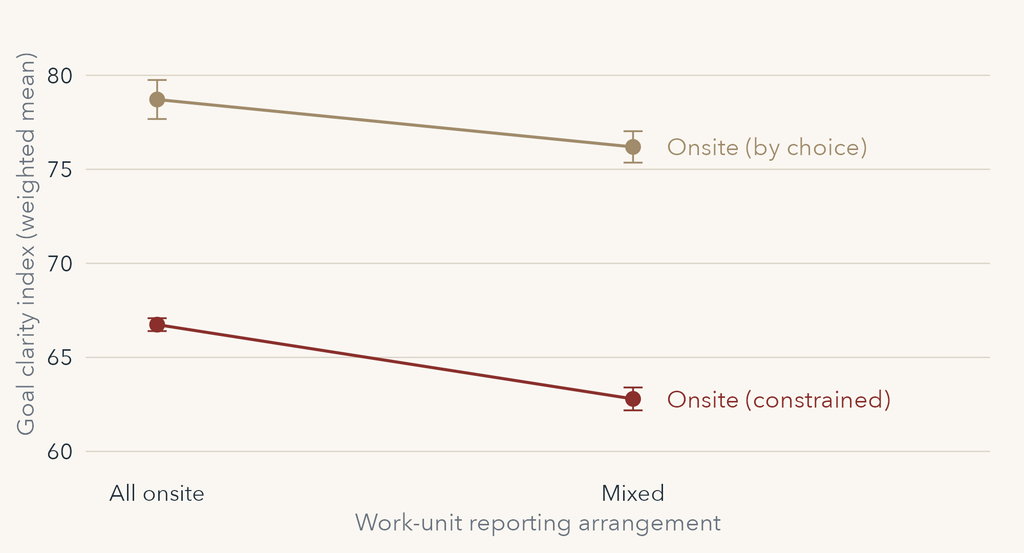

About 4 points lower with controls, and 11 percentage points more likely to say telework options have them considering leaving.

You manage a hybrid unit. What do you do for the people who have to come in?

Weighted means with 95% CIs, 2022 FEVS. An association, measured before the 2025 return-to-office order. Birdsall and Fowler, working paper.

## Parental Leave Depends on Who You Work For

12 weeks

unpaid under FMLA, if you qualify

12 weeks

paid, federal employees

8 weeks

paid, Idaho executive branch, by executive order

2 weeks

paid, Idaho Attorney General’s office, from July 1, 2026

It’s a policy, not a law. What happens to morale when a benefit is taken back?

29 U.S.C. § 2612; OPM, Paid Parental Leave; Idaho Exec. Order No. 2020-03 and DHR Statewide Policy § 10; *Idaho Statesman* (Jan. 8, 2026).

## Activity: One Benefit, Tight Budget

Your budget funds one new benefit. Each group gets one workforce.

Group 1

911 dispatchers at Ada County, on 24-hour shifts

Group 2

Analysts at an Idaho state agency

Group 3

Caseworkers at a Boise nonprofit

1. Which benefit do you fund?
2. Who gets nothing from it?

8 minutes in groups, then each group reports

## Case Study: The Blast in Centralia No. 5

## “Please Save Our Lives”

“…Governor Green this is a plea to you, to please save our lives…”

Local Union No. 52 to the Governor of Illinois, received March 9, 1946

111

men killed at Centralia No. 5, March 25, 1947

A safe workplace is one where the warning reaches someone who will act.

John Bartlow Martin, “The Blast in Centralia No. 5,” *Harper’s Magazine*, March 1948.

## Next Week…

**November 16: HR reforms and looking forward**

Guy & Sowa, Chapters 14 and 15

**Case:** Cutting the Civil Service: The 2025 Federal Workforce Reductions